# Capsule 1 - Choisir une fenêtre de lissage

MQT-2101 - Analyse et modélisation des données

## Pourquoi ça compte

Que peut-on savoir avant la semaine suivante?

Une équipe veut stabiliser sa prévision de référence sans manquer un changement durable de la demande.

## Objectifs de la capsule

- Calculer une moyenne mobile arrière.
- Expliquer le compromis entre lissage et réactivité.
- Distinguer une moyenne descriptive d’une prévision disponible au moment de décider.

## Le cas guidé

104

semaines de demande simulée

91 + 13

apprentissage puis validation

Unités

demande d’un produit

## Les mêmes cibles qu’au module 06

Origine : fin de la semaine du 22 septembre 2025. Prévoir les treize semaines du 29 septembre au 22 décembre, sans nouvelle observation.

La validation est déjà connue. Elle ne constitue pas un nouveau test indépendant.

## Une fenêtre de quatre observations

$$m_t=\frac{y_t+y_{t-1}+y_{t-2}+y_{t-3}}{4}.$$

La moyenne de 980, 1 020, 1 080 et 1 120 est de 1 050 unités. Chaque observation reçoit le même poids.

## Le compromis de la fenêtre

Courte

réaction plus rapide

Longue

davantage de lissage

Retard

les valeurs anciennes comptent

## Comparer les fenêtres sur le passé

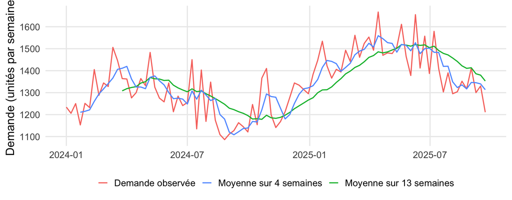

## Quand la moyenne est-elle disponible?

- La moyenne arrière au temps $t$ contient l’observation $y_t$.
- Elle peut servir à prévoir la période suivante une fois $y_t$ connue.
- Une moyenne centrée emploie aussi des observations postérieures à $t$.

## Émettre treize prévisions ensemble

$$\widehat y_{T+h\mid T}=m_T,\qquad h=1,\ldots,13.$$

À l’origine $T$, notre règle répète la dernière moyenne observée pour chacun des treize horizons $h$. Aucune demande future n’entre dans le calcul.

## À retenir

Fenêtre

poids égaux sur les k dernières observations

Disponibilité

après la dernière observation incluse

Prévision

même moyenne aux treize horizons

## Production autonome 7.1

Sur les 91 semaines d’apprentissage, tracez MM4 et MM13. Calculez la moyenne de 980, 1 020, 1 080 et 1 120 unités. Expliquez le retard d’une fenêtre longue et distinguez niveau observé et prévision à origine fixe.

### Auto-vérification

- J’ai utilisé seulement les 91 semaines d’apprentissage.
- J’obtiens 1 050 unités et je précise quand la moyenne est disponible.
- Je distingue fenêtre arrière, fenêtre centrée et prévision émise avant la cible.